# Data science project - Bigram analysis

Yingtong Guo

## Introduction to n-gram analysis

Instead of considering words as units, n-grams consider consecutive sequences of n words as units. It takes the order of the words into account. We can use n-grams to explore relationships between words and find which words often follow others immediately.

The applications of n-grams include spelling correction, sentiment classification, and text summarization. N-grams are also used in supervised machine learning models such as Naive Bayes and MaxEnt models. We can compute the probability of a sentence, a sequence of words, or an upcoming word in a probabilistic n-gram language model.

However, to calculate the co-occurrence matrix, the amount of calculation is very large. In addition, the n-gram model depends significantly on the corpus and the results of the model will vary with the value n. It is hard to use the analysis to predict the probability of word A following word B because any data is limited and it is likely to miss some perfectly acceptable word sequences.

## Bigram analysis

Here I will use bigram as an example, which is a sequence of 2 words such as “remarks by”. I will visualize the relationships between words through a network, and then explore the correlation between words.

### Visualize the most related words through a network

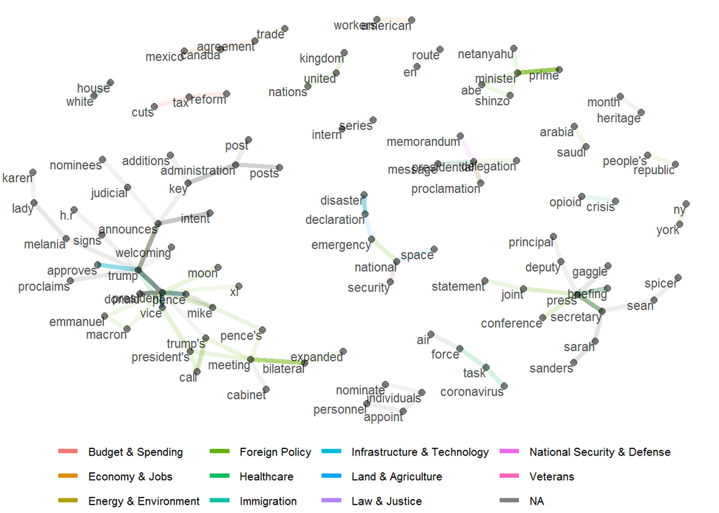

```r
#import the dataset
all <- read.csv("all.csv")
#from factor to character
all$title <- as.character(all$title)
#visualize most closely related words (words that appear together most often)
bigram <-
  all %>%
  #from sentences to bigrams
  unnest_tokens(bigram, title, token = "ngrams", n = 2) %>%
  separate(bigram, c("word1", "word2"), sep = " ") %>%
  #drop bigrams containing stopwords and digits
  filter(!word1 %in% stop_words$word) %>%
  filter(!word2 %in% stop_words$word) %>%
  filter(!str_detect(word1, "\\d")) %>%
  filter(!str_detect(word2, "\\d")) %>%
  count(word1, word2, topic, sort = TRUE) %>%
  #drop bigrams with low frequency
  filter(n > 25) %>%
  graph_from_data_frame()

#produce a network of bigrams
ggraph(bigram, layout = "fr") +
  geom_edge_link(aes(edge_alpha = n, color = topic),
                 edge_width = 1.5) +
  geom_node_point(size = 2, alpha = 0.5) +
  geom_node_text(aes(label = name), alpha = 0.7,
                 hjust = 1, vjust = 1, size = 3) +
  theme_void() +
  scale_edge_alpha(guide = 'none') +
  theme(legend.position = "bottom") +
  theme(legend.text = element_text(size = 8)) +
  theme(legend.title = element_blank())
```

I use the package `tidytext`to produce bigrams, and use packages `igraph` and `ggraph` to produce the network. The transparency of the connecting lines between points represents how often two words appear together, and the color of these lines represent the topics of the words. From the graph, we can see the four words “Canada”, “Mexico”, “trade”, “agreement” are connected. This is probably related to USMCA (United States-Mexico-Canada Agreement). The word “opioid” is connected to “crisis”, indicating a severe problem of drug abuse. However, many connections come from the regular use of different phrases, such as “white”-“house”, “prime”-“minister”, and “united”-“kingdom”, which contains little information.

### Explore the binary correlation between words

To explore the relationship between words, a better way is to examine the binary correlation. Here I will use phi coefficient, which compares the likelihood of both or neither words appearing to the likelihood of one word appearing without the other. I will use `pairwise_cor()` function in the package `widyr` to calculate the coefficient and I can see what words tend to appear together with the same topic.

```r
#calculate the correlation between words
bigram2 <-
  all %>%
  group_by(id) %>%
  #from sentences to words
  unnest_tokens(word, title) %>%
  #drop stopwords
  anti_join(stop_words) %>%
  ungroup() %>%
  #drop digits
  filter(!str_detect(word, "\\d")) %>%
  #drop words without topics
  na.omit() %>%
  group_by(word) %>%
  #drop words with low frequency
  filter(n() >= 20) %>%
  pairwise_cor(word, topic, sort = TRUE)
```

We can find the most correlated words with the word we are interested in. Here I choose “coronavirus”, “republican”, and “border” as examples.

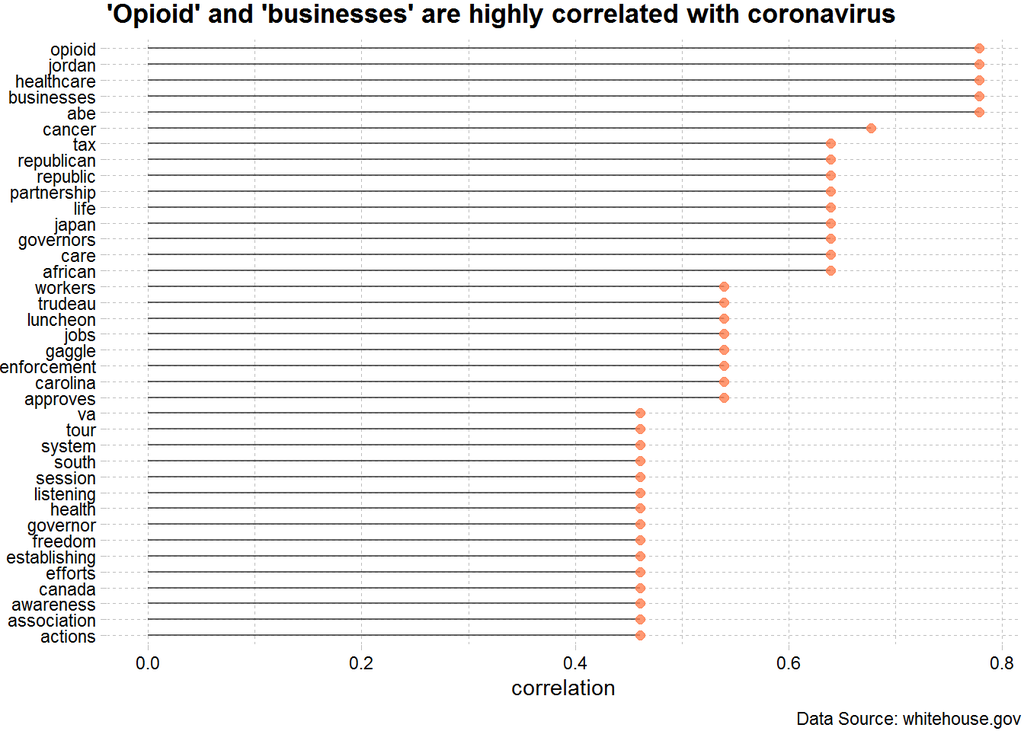

```r
coronavirus <-
  bigram2 %>%
  filter(item1 == "coronavirus")

coronavirus %>%
  top_n(30) %>%
  mutate(item2 = reorder(item2, correlation)) %>%
  ggplot(aes(x = item2, y = correlation)) +
  geom_segment(aes(xend = item2, yend = 0), alpha = 0.6) +
  geom_point(size=2, color="coral", alpha = 0.8) +
  xlab(NULL) +
  coord_flip() +
  theme_pander(base_size = 11, base_family = "sans") +
  labs(title = "'Opioid' and 'businesses' are highly correlated with coronavirus",
       caption = "Data Source: whitehouse.gov")
```

The top 5 correlated words with “coronavirus” are “opioid”, “healthcare”, “jordan”, “abe” and “businesses”. From the graph, we can see coronavirus is highly correlated with healthcare area, but it also has a large effect on businesses and people’s life. The word “freedom” is probably related to social distancing and quarantine rules. It is surprising to see “abe” and “Japan” having such a high rank.

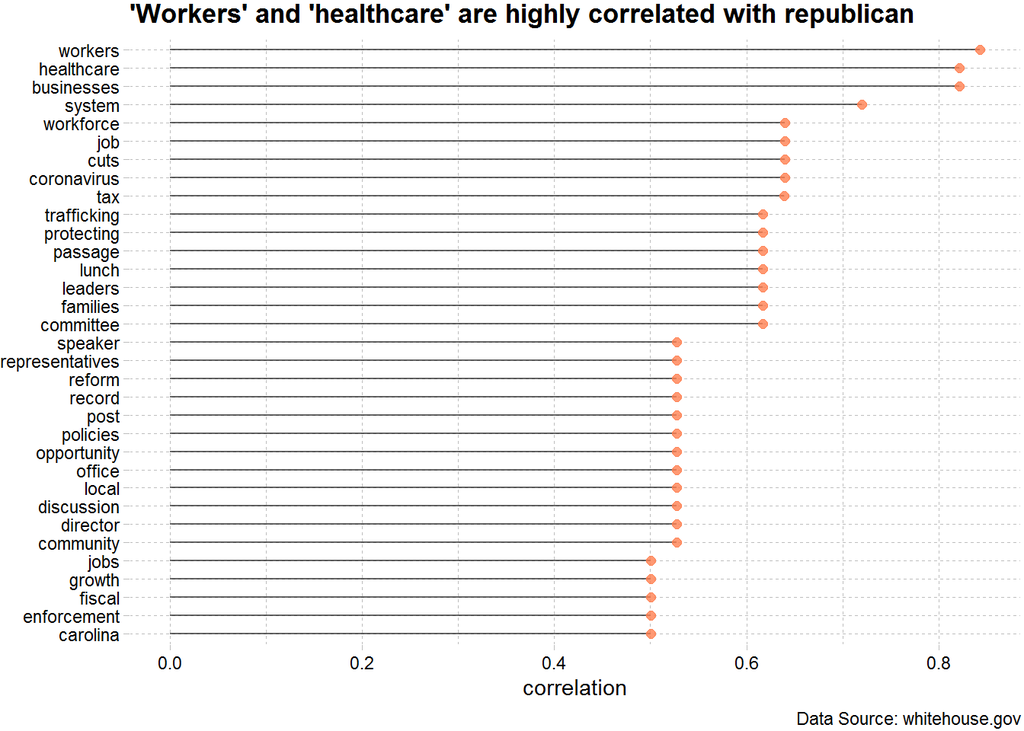

```r
republican <-
  bigram2 %>%
  filter(item1 == "republican")

republican %>%
  top_n(30) %>%
  mutate(item2 = reorder(item2, correlation)) %>%
  ggplot(aes(x = item2, y = correlation)) +
  geom_segment(aes(xend = item2, yend = 0), alpha = 0.6) +
  geom_point(size=2, color="coral", alpha = 0.8) +
  xlab(NULL) +
  coord_flip() +
  theme_pander(base_size = 11, base_family = "sans") +
  labs(title = "'Workers' and 'healthcare' are highly correlated with republican",
       caption = "Data Source: whitehouse.gov")
```

The top 3 correlated words with “republican” are “workers”, “healthcare”, and “businesses”. Most of the words are related to economy and employment, and we can also see tax cuts and coronavirus having a high rank.

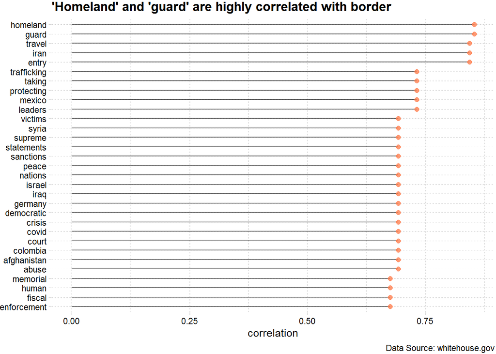

```r
border <-
  bigram2 %>%
  filter(item1 == "border")

border %>%
  top_n(30) %>%
  mutate(item2 = reorder(item2, correlation)) %>%
  ggplot(aes(x = item2, y = correlation)) +
  geom_segment(aes(xend = item2, yend = 0), alpha = 0.6) +
  geom_point(size=2, color="coral", alpha = 0.8) +
  xlab(NULL) +
  coord_flip() +
  theme_pander(base_size = 11, base_family = "sans") +
  labs(title = "'Homeland' and 'guard' are highly correlated with border",
       caption = "Data Source: whitehouse.gov")
```

Most of the words correlated with “border” are related to national security and defense or immigration fields. Some countries such as “Iran”, “Mexico”, and “Israel” are highly correlated with border.

## References

1. Silge, J., & Robinson, D. (2017). Text mining with R: A tidy approach. " O’Reilly Media, Inc.".
2. Cavnar, W. B., & Trenkle, J. M. (1994, April). N-gram-based text categorization. In Proceedings of SDAIR-94, 3rd annual symposium on document analysis and information retrieval (Vol. 161175).
3. Smith, J. R. (2018). The Application of Text Mining and Data Visualization Techniques to Textual Corpus Exploration.